# RBasic_L4

2019-03-04

## dplyr

dplyr套件 https://cran.r-project.org/web/packages/dplyr/dplyr.pdf

- filter: 篩選row
- %>% : 將當前資料集傳遞給下一個函數
- select: 篩選columns
- mutate: 新增/變化欄位
- group_by:分組
- summarise:總結
- arrange: 排序
- join: 類似excel的vlookup

## 讀取資料

```r
# install.packages('dplyr')
library(dplyr)

# 上次的大樂透作業
df <-
  read.csv(
    file = '//vibo/nfs/CHPublic/客戶服務事業部/部門公用區/R語言課程/HW2/課程內容及題目/Lottery.csv',
    fileEncoding = 'UTF-8')

# 各區銷售負責人
df2 <- read.csv(file = 'https://s.yam.com/Qdbh5',
                fileEncoding = 'UTF-8')
```

## 上次的回家作業

在西元2100年，由於受到少子化危機的影響，人口數越來越少，於是各縣市掀開了一波搶人大戰…  
為了鼓勵人口移入，各縣市紛紛提出「縣市祝福」專案，  
高雄市說：「你來，中多少錢我都再多給你1倍!」(共2倍)  
桃園市說：「來我這！我再多給你2倍！」(共3倍)  
台北市說：「不要理他們，我再多4倍！」(共5倍)  
其他縣市則由於財政問題，無法提供縣市祝福

```r
head(df)
```

```
##   ID   出生日期   購買日期 性別 投注金額 中獎金額 購買地區 宗教信仰
## 1  1 1971-06-29 2018-07-20   女      100        0     高雄     佛教
## 2  2 1986-10-19 2018-09-19   女      150        0     花蓮     佛教
## 3  3 1976-06-15 2018-08-09   女       50        0     台東   基督教
## 4  4 1971-02-17 2018-07-18   男      150        0     台中       無
## 5  5 1959-12-24 2018-06-04   男      250        0     新竹     佛教
## 6  6 1980-06-03 2018-08-24   男      100        0     彰化     佛教
```

```r
# 請上網搜尋dplyr套件中的case_when函數
# 透過中獎金額，計算出在縣市祝福後，每個人會領到多少錢？
# df3 <- df %>%
#   mutate(實領金額 = case_when(
#
#   ))
```

## 上次的回家作業

具體的轉換條件如下

- 高雄市 → 中獎金額 * 2
- 桃園市 → 中獎金額 * 3
- 台北市 → 中獎金額 * 5
- 其他縣市 → 維持原中獎金額

```r
df3 <- df %>%
 mutate(
   實領金額 = case_when(
     grepl('高雄', 購買地區) ~ 中獎金額 * 2,
     grepl('桃園', 購買地區) ~ 中獎金額 * 3,
     grepl('台北', 購買地區) ~ 中獎金額 * 5,
     TRUE ~ 中獎金額))
```

## group_by

正常情況下，我們拿到的都只是原始資料，需要經過分組處理後才會有意義，如：  
- 每位Agent/每個組別點了多少個Calltype  
- 催收員打了多少通電話/回收多少錢  
- …

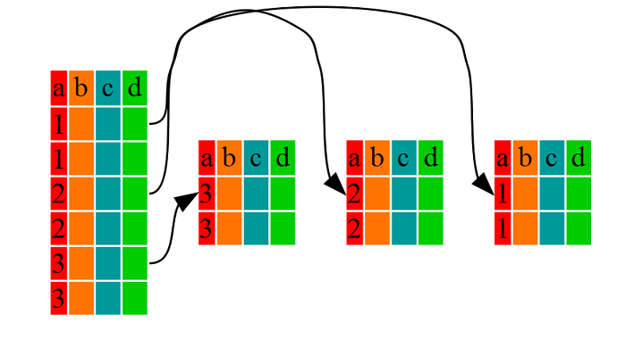

group

## summarise

而整理資料的方法就是運用group_by與summarise函數！  
例如我想要知道各縣市分別有多少筆訂單…

```r
df %>%
  group_by(購買地區) %>%
  summarise(count = n())
```

```
## # A tibble: 19 x 2
##    購買地區  count
##    <fct>     <int>
##  1 台中     159580
##  2 台北     220303
##  3 台東      59485
##  4 台南     139990
##  5 外島      39978
##  6 宜蘭     119755
##  7 花蓮     119652
##  8 南投      59692
##  9 屏東     140567
## 10 苗栗      79987
## 11 苗粟          1
## 12 桃園      60043
## 13 紐約          1
## 14 高雄     200664
## 15 雲林      99979
## 16 新北     200310
## 17 新竹     179943
## 18 嘉義      39969
## 19 彰化      80101
```

## 練習1：group_by & summarise 組合應用

那如果我想知道各縣市的總投注金額呢？

```r
# df %>%
#   group_by(購買地區) %>%
#   summarise(總投注金額 = ...)
```

## 解答1：group_by & summarise 組合應用

那如果我想知道各縣市的總投注金額呢？

```r
df %>%
  group_by(購買地區) %>%
  summarise(總投注金額 = sum(投注金額))
```

```
## # A tibble: 19 x 2
##    購買地區 總投注金額
##    <fct>         <int>
##  1 台中       23780150
##  2 台北       32826100
##  3 台東        8872000
##  4 台南       20876800
##  5 外島        5967000
##  6 宜蘭       17838900
##  7 花蓮       17846250
##  8 南投        8925300
##  9 屏東       20933950
## 10 苗栗       11902050
## 11 苗粟             50
## 12 桃園        8920747
## 13 紐約            150
## 14 高雄       29876750
## 15 雲林       14919950
## 16 新北       29778250
## 17 新竹       26831400
## 18 嘉義        5988850
## 19 彰化       11925200
```

## Join

有時候資訊會散落在不同的表格，需要透過比對來整合資訊  
(如excel的vlookup函數)  
- 例如在計算客服人員的產值時，每個calltype有不同的產值分數

```r
head(df, 3)
```

```
##   ID   出生日期   購買日期 性別 投注金額 中獎金額 購買地區 宗教信仰
## 1  1 1971-06-29 2018-07-20   女      100        0     高雄     佛教
## 2  2 1986-10-19 2018-09-19   女      150        0     花蓮     佛教
## 3  3 1976-06-15 2018-08-09   女       50        0     台東   基督教
```

```r
head(df2, 3)
```

```
##   購買地區  人口數 經銷區長 經銷經理
## 1     台北 2666908    Jerry    Nancy
## 2     新北 3997189    Jerry    Nancy
## 3     桃園 2223733    Carol    Nancy
```

## Join

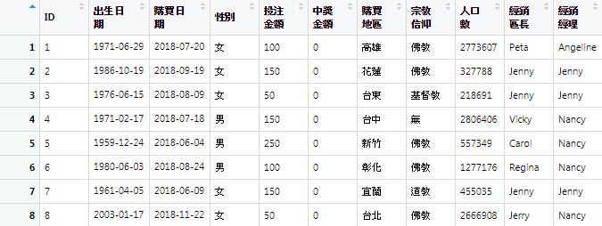

```r
df4 <- left_join(df, df2, by = '購買地區')
View(df4)
```

## 練習題2

- 各區長有多少筆訂單
- 各區長的投注總金額是多少？

```r
df4 %>%
  group_by(經銷區長)%>%
  summarise(投注訂單量 = n(),
            總投注金額 = sum(投注金額))
```

```
## # A tibble: 7 x 3
##   經銷區長 投注訂單量 總投注金額
##   <fct>         <int>      <int>
## 1 Carol        239986   35752147
## 2 Jenny        338872   50524350
## 3 Jerry        420613   62604350
## 4 Peta         481221   71687500
## 5 Pokey        139948   20908800
## 6 Regina       139793   20850500
## 7 Vicky        239567   35682200
```

## Join家族

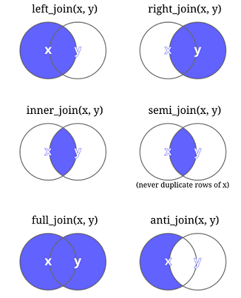

from http://rstudio-pubs-static.s3.amazonaws.com/227171_618ebdce0b9d44f3af65700e833593db.html

## 回家作業： 誰是大賣家?

為了要刺激競爭提升銷售績效，公司決定幫各區區長打考核成績

考核成績計算公式如下：  
市場開發度(60%) + 銷售積分(40%)

市場開發度：轄區購買人數/轄區人口數

銷售積分：  
- 投注金額 >= 1000 → 3分  
- 投注金額 >= 500 → 2分  
- 投注金額 >= 50 → 1分

請運用mutate, summarise, case_when, group_by等函數，  
幫各區區長計算「市場開發度」、「銷售積分」與「考核成績」等三項分數~